# Advance Clustering

Achmad Fauzi Bagus F

September 3rd, 2016

`advclust` is package for advance clustering. Right now `advclust` provide several Fuzzy Clustering and Consensus Fuzzy Clustering. This package use Object Oriented Programming (S4 for R). Several Algorithms that provided by this package are: - Fuzzy C-Means (FCM) - Gustafson Kessel (GK) - Gath Geva (GG) - Sum Voting Consensus - Product Voting Consensus - Borda Voting Consensus

## Fuzzy Clustering Analysis

### Fuzzy C-Means

`fuzzy.CM()` perform fuzzy c-means analysis. More description of this function (parameter setting, description, and return value) explained via `?fuzzy.CM` This algorithm used to get sperichal cluster

```r
library(advclust)
data(iris)
fuzzy.CM(X=iris[,1:4],K = 3,m = 2,RandomNumber = 1234)->cl_CM
```

[output not shown]

```r
show(cl_CM)
```

```
## Function call: fuzzy.CM(X = iris[, 1:4], K = 3, m = 2, RandomNumber = 1234)
## Fuzzy C-Means
## Function objective: 60.5057106294886
## Membership & Label Matrix:
##
##            Cluster 1   Cluster 2   Cluster 3   Label
## --------  ----------  ----------  ----------  ------
## Obs 1          0.002       0.997       0.001       2
## Obs 2          0.017       0.976       0.007       2
## Obs 3          0.014       0.980       0.006       2
## Obs 4          0.022       0.967       0.010       2
## Obs 5          0.004       0.994       0.002       2
## Obs 6          0.045       0.935       0.021       2
## Obs 7          0.014       0.979       0.007       2
## Obs 8          0.000       1.000       0.000       2
## Obs 9          0.048       0.930       0.022       2
## Obs 10         0.012       0.983       0.005       2
## Obs 11         0.022       0.968       0.010       2
## Obs 12         0.005       0.992       0.002       2
## Obs 13         0.020       0.971       0.009       2
## Obs 14         0.052       0.923       0.025       2
## Obs 15         0.073       0.890       0.038       2
## Obs 16         0.104       0.841       0.054       2
## Obs 17         0.036       0.947       0.017       2
## Obs 18         0.002       0.997       0.001       2
## Obs 19         0.066       0.904       0.030       2
## Obs 20         0.014       0.979       0.007       2
## Obs 21         0.022       0.969       0.010       2
## Obs 22         0.010       0.985       0.005       2
## Obs 23         0.028       0.959       0.014       2
## Obs 24         0.014       0.979       0.006       2
## Obs 25         0.023       0.967       0.010       2
## Obs 26         0.018       0.974       0.008       2
## Obs 27         0.004       0.995       0.002       2
## Obs 28         0.005       0.993       0.002       2
## Obs 29         0.004       0.994       0.002       2
## Obs 30         0.014       0.980       0.006       2
## Obs 31         0.015       0.979       0.006       2
## Obs 32         0.018       0.974       0.008       2
## Obs 33         0.041       0.939       0.020       2
```

[output cut: 110 more lines]

```
## Obs 144        0.034       0.005       0.961       3
## Obs 145        0.063       0.010       0.927       3
## Obs 146        0.106       0.011       0.882       3
## Obs 147        0.508       0.026       0.467       1
## Obs 148        0.156       0.012       0.831       3
## Obs 149        0.189       0.022       0.789       3
## Obs 150        0.582       0.027       0.391       1
##
## Centroid:
##
##              Sepal.Length   Sepal.Width   Petal.Length   Petal.Width
## ----------  -------------  ------------  -------------  ------------
## Cluster 1           5.889         2.761          4.364         1.397
## Cluster 2           5.004         3.414          1.483         0.254
## Cluster 3           6.775         3.052          5.647         2.054
```

### Gustafson Kessel

`fuzzy.GK()` perform Gustafson Kessel analysis. More description of this function (parameter setting, description, and return value) explained via `?fuzzy.GK`. This algorithm used to get ellipsodial and sperichal cluster

```r
library(advclust)
data(iris)
fuzzy.GK(X=iris[,1:4],K = 3,m = 2,RandomNumber = 1234)->cl_GK
```

[output not shown]

[output cut: 169 more lines]

[output not shown]

```r
show(cl_GK)
```

```
## Function call: fuzzy.GK(X = iris[, 1:4], K = 3, m = 2, RandomNumber = 1234)
## Gustafson Kessel Clustering
## Function objective: 31.5266810464968
## Membership & Label Matrix:
##
##            Cluster 1   Cluster 2   Cluster 3   Label
## --------  ----------  ----------  ----------  ------
## Obs 1          0.003       0.995       0.001       2
## Obs 2          0.032       0.957       0.011       2
## Obs 3          0.015       0.979       0.005       2
## Obs 4          0.024       0.967       0.009       2
## Obs 5          0.006       0.992       0.002       2
## Obs 6          0.027       0.962       0.011       2
## Obs 7          0.041       0.944       0.015       2
## Obs 8          0.003       0.995       0.001       2
## Obs 9          0.051       0.932       0.017       2
## Obs 10         0.037       0.948       0.015       2
## Obs 11         0.015       0.979       0.006       2
## Obs 12         0.021       0.970       0.009       2
## Obs 13         0.037       0.949       0.014       2
## Obs 14         0.075       0.899       0.026       2
## Obs 15         0.050       0.929       0.022       2
## Obs 16         0.040       0.942       0.018       2
## Obs 17         0.042       0.942       0.016       2
## Obs 18         0.007       0.990       0.003       2
## Obs 19         0.036       0.949       0.015       2
## Obs 20         0.014       0.980       0.006       2
## Obs 21         0.047       0.933       0.020       2
## Obs 22         0.027       0.963       0.010       2
## Obs 23         0.074       0.898       0.028       2
## Obs 24         0.088       0.884       0.028       2
## Obs 25         0.081       0.879       0.041       2
## Obs 26         0.050       0.932       0.018       2
## Obs 27         0.029       0.961       0.010       2
## Obs 28         0.008       0.989       0.003       2
## Obs 29         0.013       0.982       0.005       2
## Obs 30         0.026       0.964       0.010       2
## Obs 31         0.025       0.965       0.009       2
## Obs 32         0.052       0.929       0.019       2
## Obs 33         0.042       0.937       0.021       2
```

[output cut: 110 more lines]

```
## Obs 144        0.082       0.005       0.914       3
## Obs 145        0.070       0.009       0.921       3
## Obs 146        0.118       0.018       0.865       3
## Obs 147        0.244       0.018       0.738       3
## Obs 148        0.037       0.002       0.961       3
## Obs 149        0.132       0.015       0.853       3
## Obs 150        0.266       0.011       0.723       3
##
## Centroid:
##
##              Sepal.Length   Sepal.Width   Petal.Length   Petal.Width
## ----------  -------------  ------------  -------------  ------------
## Cluster 1           6.128         2.802          4.510         1.402
## Cluster 2           5.014         3.438          1.465         0.244
## Cluster 3           6.398         2.975          5.305         2.015
```

### Gath Geva

`fuzzy.GG()` perform Gath Geva analysis. More description of this function (parameter setting, description, and return value) explained via `?fuzzy.GG` This algorithm used to get hyperellipsodial cluster. Use membership that resulted from `fuzzy.CM` as initial membership to get best result.

```r
library(advclust)
data(iris)
fuzzy.GG(X=iris[,1:4],K = 3,m = 2,RandomNumber = 1234)->cl_GG
```

[output not shown]

[output cut: 159 more lines]

[output not shown]

```r
show(cl_GG)
```

```
## Function call: fuzzy.GG(X = iris[, 1:4], K = 3, m = 2, RandomNumber = 1234)
## Gath Geva Clustering
## Function objective: 6.37182273445943e+60
## Membership & Label Matrix:
##
##            Cluster 1   Cluster 2   Cluster 3   Label
## --------  ----------  ----------  ----------  ------
## Obs 1          0.004       0.995       0.001       2
## Obs 2          0.048       0.940       0.012       2
## Obs 3          0.017       0.979       0.004       2
## Obs 4          0.035       0.955       0.010       2
## Obs 5          0.006       0.992       0.002       2
## Obs 6          0.025       0.966       0.008       2
## Obs 7          0.053       0.932       0.015       2
## Obs 8          0.005       0.993       0.002       2
## Obs 9          0.073       0.909       0.018       2
## Obs 10         0.050       0.934       0.015       2
## Obs 11         0.021       0.973       0.007       2
## Obs 12         0.029       0.961       0.009       2
## Obs 13         0.052       0.934       0.015       2
## Obs 14         0.065       0.918       0.017       2
## Obs 15         0.058       0.921       0.020       2
## Obs 16         0.056       0.923       0.021       2
## Obs 17         0.055       0.927       0.018       2
## Obs 18         0.011       0.986       0.003       2
## Obs 19         0.040       0.947       0.013       2
## Obs 20         0.020       0.973       0.007       2
## Obs 21         0.050       0.933       0.016       2
## Obs 22         0.033       0.958       0.010       2
## Obs 23         0.052       0.934       0.015       2
## Obs 24         0.055       0.932       0.014       2
## Obs 25         0.089       0.877       0.034       2
## Obs 26         0.057       0.927       0.016       2
## Obs 27         0.019       0.976       0.005       2
## Obs 28         0.011       0.986       0.003       2
## Obs 29         0.019       0.976       0.005       2
## Obs 30         0.034       0.956       0.010       2
## Obs 31         0.028       0.963       0.008       2
## Obs 32         0.066       0.916       0.019       2
## Obs 33         0.055       0.923       0.022       2
```

[output cut: 110 more lines]

```
## Obs 144        0.088       0.041       0.872       3
## Obs 145        0.067       0.051       0.883       3
## Obs 146        0.113       0.103       0.784       3
## Obs 147        0.232       0.149       0.619       3
## Obs 148        0.041       0.018       0.941       3
## Obs 149        0.132       0.083       0.785       3
## Obs 150        0.302       0.091       0.607       3
##
## Centroid:
##
##              Sepal.Length   Sepal.Width   Petal.Length   Petal.Width
## ----------  -------------  ------------  -------------  ------------
## Cluster 1           6.194         2.831          4.615         1.440
## Cluster 2           5.058         3.403          1.609         0.302
## Cluster 3           6.420         2.996          5.333         2.053
```

## Visualization

For visualization this package provide biplot and radar plot

### Biplot

Biplot perform visualization with Principal Component Analysis. Use scale =`T` when unit of variables on data are different.

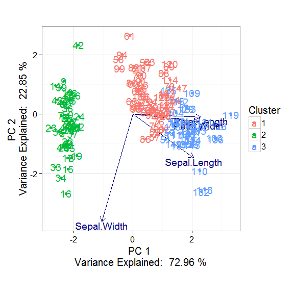

```r
biploting(cl_CM, iris[,1:4], scale=T)->biplot
```

### Radar Plot

Radar plot can be used to profilling your cluster result via centroid. Please take attention to axis label. `0` indicates mean of variable, `0.5` indicates mean plus half of standar deviation in realted variable, `-0.5` indicates mean minus half of standar deviation in related variable, etc.

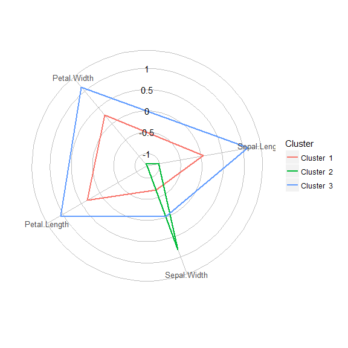

```r
radar.plotting(cl_CM, iris[,1:4])->radar
```

## Validation

To get best parameter and know how well your result, use validation index that provided. There are Xie Beni, Partition Coefficient, Modified Partition Coefficient, Classification Entropy, Kwon, Tang, and Separation. See details in `?validation.index`

```r
validation.index(cl_GK)
```

```
## Validation Index result:
##
##                                    Value
## -------------------------------  -------
## Partition Coefficient              0.728
## Modified Partition Coefficient     0.592
## Classification Entropy             0.466
## Xie Beni                           0.189
## Separation                         0.189
## Kwon                              48.454
## Tang                              38.430
```

## Consensus Clustering

Combine several fuzzy cluster result, eg: FCM, GK, GG, to one result. The purpose of this action is to get best stable or robust result. Actually when you run 3 times, with no specific random number, the first result may be different with second time. And choosing best random number is hard to describe. So the alternative is you can combine your result with consensus algorithm.

Right now, this package provide VOTING method. This method inspired from domination in voting schema. Algorithm that use in this package are “sum”, “product”, “borda”. “product” is sensitive when there is low membership on your result.

```r
c_fuzzycluster(cl_GK,cl_GG,cl_CM)->c_consensus
co.vote(c_consensus,"sum")
```

```
## Method of Consensus used:    Vote-sum
## Ensemble/Consensus Membership:
##
##            Cluster 1   Cluster 2   Cluster 3
## --------  ----------  ----------  ----------
## Obs 1          0.003       0.995       0.001
## Obs 2          0.032       0.957       0.010
## Obs 3          0.015       0.979       0.005
## Obs 4          0.027       0.963       0.010
## Obs 5          0.005       0.993       0.002
## Obs 6          0.032       0.954       0.013
## Obs 7          0.036       0.952       0.012
## Obs 8          0.003       0.996       0.001
## Obs 9          0.057       0.924       0.019
## Obs 10         0.033       0.955       0.012
## Obs 11         0.019       0.973       0.008
## Obs 12         0.019       0.974       0.007
## Obs 13         0.036       0.951       0.013
## Obs 14         0.064       0.913       0.023
## Obs 15         0.060       0.913       0.027
## Obs 16         0.067       0.902       0.031
## Obs 17         0.044       0.939       0.017
## Obs 18         0.007       0.991       0.002
## Obs 19         0.047       0.933       0.020
## Obs 20         0.016       0.977       0.006
## Obs 21         0.040       0.945       0.015
## Obs 22         0.023       0.968       0.008
## Obs 23         0.051       0.930       0.019
## Obs 24         0.052       0.932       0.016
## Obs 25         0.064       0.908       0.028
## Obs 26         0.042       0.944       0.014
## Obs 27         0.017       0.977       0.006
## Obs 28         0.008       0.990       0.003
## Obs 29         0.012       0.984       0.004
## Obs 30         0.025       0.966       0.009
## Obs 31         0.023       0.969       0.008
## Obs 32         0.045       0.940       0.015
## Obs 33         0.046       0.933       0.021
## Obs 34         0.042       0.939       0.019
## Obs 35         0.017       0.977       0.006
```

[output cut: 255 more lines]

```
## Obs 136        3
## Obs 137        3
## Obs 138        3
## Obs 139        3
## Obs 140        3
## Obs 141        3
## Obs 142        3
## Obs 143        3
## Obs 144        3
## Obs 145        3
## Obs 146        3
## Obs 147        3
## Obs 148        3
## Obs 149        3
## Obs 150        3
```